# TSFRESH

# Feature Extraction and Selection

This basic example shows how to use [tsfresh](https://tsfresh.readthedocs.io/) to extract useful features from multiple timeseries and use them to improve classification performance.

We use the robot execution failure data set as an example.

## Load and visualize data

The data set documents 88 robot executions (each has a unique `id` between 1 and 88), which is a subset of the [Robot Execution Failures Data Set](https://archive.ics.uci.edu/ml/datasets/Robot+Execution+Failures). For the purpose of simplicity we are only differentiating between successfull and failed executions (`y`).

For each execution 15 force (F) and torque (T) samples are given, which were measured at regular time intervals for the spatial dimensions x, y, and z. Therefore each row of the data frame references a specific execution (`id`), a time index (`index`) and documents the respective measurements of 6 sensors (`F_x`, `F_y`, `F_z`, `T_x`, `T_y`, `T_z`).

```python
from tsfresh.examples import robot_execution_failures

robot_execution_failures.download_robot_execution_failures()
df, y = robot_execution_failures.load_robot_execution_failures()
df.head()
```

|  | id | time | F_x | F_y | F_z | T_x | T_y | T_z |
| --- | --- | --- | --- | --- | --- | --- | --- | --- |
| 0 | 1 | 0 | -1 | -1 | 63 | -3 | -1 | 0 |
| 1 | 1 | 1 | 0 | 0 | 62 | -3 | -1 | 0 |
| 2 | 1 | 2 | -1 | -1 | 61 | -3 | 0 | 0 |
| 3 | 1 | 3 | -1 | -1 | 63 | -2 | -1 | 0 |
| 4 | 1 | 4 | -1 | -1 | 63 | -3 | -1 | 0 |

Let's draw some example executions:

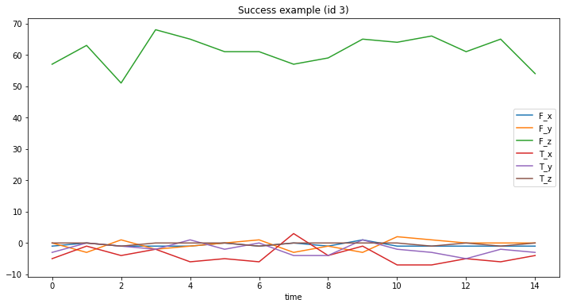

```python
df[df.id == 3][['time', 'F_x', 'F_y', 'F_z', 'T_x', 'T_y', 'T_z']].plot(x='time', title='Success example (id 3)', figsize=(12, 6));
```

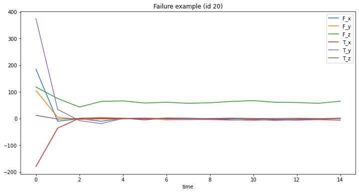

```python
df[df.id == 20][['time', 'F_x', 'F_y', 'F_z', 'T_x', 'T_y', 'T_z']].plot(x='time', title='Failure example (id 20)', figsize=(12, 6));
```

## Extract Features

We can use the data to extract time series features using `tsfresh`. We want to extract features for each time series, that means for each robot execution (which is our `id`) and for each of the measured sensor values (`F_*` and `T_*`).

You can think of it like this: tsfresh will result in a single row for each `id` and will calculate the features for each columns (we call them "kind") separately.

The `time` column is our sorting column. For an overview on the data formats of `tsfresh`, please have a look at [the documentation](https://tsfresh.readthedocs.io/en/latest/text/data_formats.html).

```python
# We are very explicit here and specify the `default_fc_parameters`. If you remove this argument,
# the ComprehensiveFCParameters (= all feature calculators) will also be used as default.
# Have a look into the documentation (https://tsfresh.readthedocs.io/en/latest/text/feature_extraction_settings.html)
# or one of the other notebooks to learn more about this.
extraction_settings = ComprehensiveFCParameters()

X = extract_features(df, column_id='id', column_sort='time',
                     default_fc_parameters=extraction_settings,
                     # we impute = remove all NaN features automatically
                     impute_function=impute)
```

`X` now contains for each robot execution (= `id`) a single row, with all the features `tsfresh` calculated based on the measured times series values for this `id`.

```python
X.head()
```

|  | F_x__variance_larger_than_standard_deviation | F_x__has_duplicate_max | F_x__has_duplicate_min | F_x__has_duplicate | F_x__sum_values | F_x__abs_energy | F_x__mean_abs_change | F_x__mean_change | F_x__mean_second_derivative_central | F_x__median | ... | T_z__permutation_entropy__dimension_6__tau_1 | T_z__permutation_entropy__dimension_7__tau_1 | T_z__query_similarity_count__query_None__threshold_0.0 | T_z__matrix_profile__feature_"min"__threshold_0.98 | T_z__matrix_profile__feature_"max"__threshold_0.98 | T_z__matrix_profile__feature_"mean"__threshold_0.98 | T_z__matrix_profile__feature_"median"__threshold_0.98 | T_z__matrix_profile__feature_"25"__threshold_0.98 | T_z__matrix_profile__feature_"75"__threshold_0.98 | T_z__mean_n_absolute_max__number_of_maxima_7 |
| --- | --- | --- | --- | --- | --- | --- | --- | --- | --- | --- | --- | --- | --- | --- | --- | --- | --- | --- | --- | --- | --- |
| 1 | 0.0 | 0.0 | 1.0 | 1.0 | -14.0 | 14.0 | 0.142857 | 0.000000 | -0.038462 | -1.0 | ... | -0.000000 | -0.000000 | 0.0 | 0.0 | 0.0 | 0.0 | 0.0 | 0.0 | 0.0 | 0.000000 |
| 2 | 0.0 | 1.0 | 1.0 | 1.0 | -13.0 | 25.0 | 1.000000 | 0.000000 | -0.038462 | -1.0 | ... | 1.748067 | 1.831020 | 0.0 | 0.0 | 0.0 | 0.0 | 0.0 | 0.0 | 0.0 | 0.571429 |
| 3 | 0.0 | 0.0 | 1.0 | 1.0 | -10.0 | 12.0 | 0.714286 | 0.000000 | -0.038462 | -1.0 | ... | 2.163956 | 2.197225 | 0.0 | 0.0 | 0.0 | 0.0 | 0.0 | 0.0 | 0.0 | 0.571429 |
| 4 | 0.0 | 1.0 | 1.0 | 1.0 | -6.0 | 16.0 | 1.214286 | -0.071429 | -0.038462 | 0.0 | ... | 2.302585 | 2.197225 | 0.0 | 0.0 | 0.0 | 0.0 | 0.0 | 0.0 | 0.0 | 1.000000 |
| 5 | 0.0 | 0.0 | 0.0 | 1.0 | -9.0 | 17.0 | 0.928571 | -0.071429 | 0.038462 | -1.0 | ... | 2.302585 | 2.197225 | 0.0 | 0.0 | 0.0 | 0.0 | 0.0 | 0.0 | 0.0 | 0.857143 |

5 rows × 4734 columns

## Select Features

Using the hypothesis tests implemented in `tsfresh` (see [here](https://tsfresh.readthedocs.io/en/latest/text/feature_filtering.html) for more information) it is now possible to select only the relevant features out of this large dataset.

`tsfresh` will do a hypothesis test for each of the features to check, if it is relevant for your given target.

```python
X_filtered = select_features(X, y)
```

```python
X_filtered.head()
```

|  | F_x__value_count__value_-1 | F_x__abs_energy | F_x__root_mean_square | T_y__absolute_maximum | F_x__mean_n_absolute_max__number_of_maxima_7 | F_x__range_count__max_1__min_-1 | F_y__abs_energy | F_y__root_mean_square | F_y__mean_n_absolute_max__number_of_maxima_7 | T_y__variance | ... | F_y__cwt_coefficients__coeff_14__w_5__widths_(2, 5, 10, 20) | F_y__cwt_coefficients__coeff_13__w_2__widths_(2, 5, 10, 20) | T_y__lempel_ziv_complexity__bins_3 | T_y__quantile__q_0.1 | F_z__time_reversal_asymmetry_statistic__lag_1 | F_x__quantile__q_0.2 | F_y__quantile__q_0.7 | T_x__change_quantiles__f_agg_"var"__isabs_False__qh_0.2__ql_0.0 | T_z__large_standard_deviation__r_0.35000000000000003 | T_z__quantile__q_0.9 |
| --- | --- | --- | --- | --- | --- | --- | --- | --- | --- | --- | --- | --- | --- | --- | --- | --- | --- | --- | --- | --- | --- |
| 1 | 14.0 | 14.0 | 0.966092 | 1.0 | 1.000000 | 15.0 | 13.0 | 0.930949 | 1.000000 | 0.222222 | ... | -0.751682 | -0.310265 | 0.400000 | -1.0 | -596.000000 | -1.0 | -1.0 | 0.0 | 0.0 | 0.0 |
| 2 | 7.0 | 25.0 | 1.290994 | 5.0 | 1.571429 | 13.0 | 76.0 | 2.250926 | 3.000000 | 4.222222 | ... | 0.057818 | -0.202951 | 0.533333 | -3.6 | -680.384615 | -1.0 | -1.0 | 0.0 | 1.0 | 0.0 |
| 3 | 11.0 | 12.0 | 0.894427 | 5.0 | 1.000000 | 14.0 | 40.0 | 1.632993 | 2.142857 | 3.128889 | ... | 0.912474 | 0.539121 | 0.533333 | -4.0 | -617.000000 | -1.0 | 0.0 | 0.0 | 1.0 | 0.0 |
| 4 | 5.0 | 16.0 | 1.032796 | 6.0 | 1.285714 | 10.0 | 60.0 | 2.000000 | 2.428571 | 7.128889 | ... | -0.609735 | -2.641390 | 0.533333 | -4.6 | 3426.307692 | -1.0 | 1.0 | 0.0 | 0.0 | 0.0 |
| 5 | 9.0 | 17.0 | 1.064581 | 5.0 | 1.285714 | 13.0 | 46.0 | 1.751190 | 2.285714 | 4.160000 | ... | 0.072771 | 0.591927 | 0.466667 | -5.0 | -2609.000000 | -1.0 | 0.8 | 0.0 | 0.0 | 0.6 |

5 rows × 682 columns

## Train and evaluate classifier

```python
X_full_train, X_full_test, y_train, y_test = train_test_split(X, y, test_size=.4)
X_filtered_train, X_filtered_test = X_full_train[X_filtered.columns], X_full_test[X_filtered.columns]
```

```python
classifier_full = DecisionTreeClassifier()
classifier_full.fit(X_full_train, y_train)
print(classification_report(y_test, classifier_full.predict(X_full_test)))
```

```
              precision    recall  f1-score   support

       False       1.00      0.79      0.88        28
        True       0.57      1.00      0.73         8

    accuracy                           0.83        36
   macro avg       0.79      0.89      0.80        36
weighted avg       0.90      0.83      0.85        36
```

```python
classifier_filtered = DecisionTreeClassifier()
classifier_filtered.fit(X_filtered_train, y_train)
print(classification_report(y_test, classifier_filtered.predict(X_filtered_test)))
```

```
              precision    recall  f1-score   support

       False       1.00      0.89      0.94        28
        True       0.73      1.00      0.84         8

    accuracy                           0.92        36
   macro avg       0.86      0.95      0.89        36
weighted avg       0.94      0.92      0.92        36
```

Compared to using all features (`classifier_full`), using only the relevant features (`classifier_filtered`) achieves better classification performance with less data.

Please remember that the hypothesis test in `tsfresh` is a statistical test. You might get better performance with other feature selection methods (e.g. training a classifier with all but one feature to find its importance) - but in general the feature selection implemented in `tsfresh` will give you a very reasonable set of selected features.

## Extraction and Filtering is the same as filtered Extraction

Above, we performed the feature extraction and selection independently. If you are only interested in the list of selected features, you can run this in one step:

```python
X_filtered_2 = extract_relevant_features(df, y, column_id='id', column_sort='time',
                                         default_fc_parameters=extraction_settings)
```

```python
(X_filtered.columns == X_filtered_2.columns).all()
```

```
True
```

# Feature Selection in a sklearn pipeline

This notebook is quite similar to the first example. This time however, we use the `sklearn` pipeline API of `tsfresh`. If you want to learn more, have a look at [the documentation](https://tsfresh.readthedocs.io/en/latest/text/sklearn_transformers.html).

## Load and Prepare the Data

Check out the first example notebook to learn more about the data and format.

```python
from tsfresh.examples.robot_execution_failures import download_robot_execution_failures
download_robot_execution_failures()
df_ts, y = load_robot_execution_failures()
```

We want to use the extracted features to predict for each of the robot executions, if it was a failure or not. Therefore our basic "entity" is a single robot execution given by a distinct `id`.

A dataframe with these identifiers as index needs to be prepared for the pipeline.

```python
X = pd.DataFrame(index=y.index)

# Split data into train and test set
X_train, X_test, y_train, y_test = train_test_split(X, y)
```

## Build the pipeline

We build a sklearn pipeline that consists of a feature extraction step (`RelevantFeatureAugmenter`) with a subsequent `RandomForestClassifier`.

The `RelevantFeatureAugmenter` takes roughly the same arguments as `extract_features` and `select_features` do.

```python
ppl = Pipeline([
        ('augmenter', RelevantFeatureAugmenter(column_id='id', column_sort='time')),
        ('classifier', RandomForestClassifier())
      ])
```

Here comes the tricky part! The input to the pipeline will be our dataframe `X`, which one row per identifier. It is currently empty. But which time series data should the `RelevantFeatureAugmenter` to actually extract the features from? We need to pass the time series data (stored in `df_ts`) to the transformer.

In this case, df_ts contains the time series of both train and test set, if you have different dataframes for train and test set, you have to call set_params two times (see further below on how to deal with two independent data sets)

```python
ppl.set_params(augmenter__timeseries_container=df_ts);
```

We are now ready to fit the pipeline

```python
ppl.fit(X_train, y_train)
```

[output not shown]

```
Pipeline(steps=[('augmenter',
                 RelevantFeatureAugmenter(column_id='id', column_sort='time',
                                          timeseries_container=      id  time  F_x  F_y  F_z  T_x  T_y  T_z
0      1     0   -1   -1   63   -3   -1    0
1      1     1    0    0   62   -3   -1    0
2      1     2   -1   -1   61   -3    0    0
3      1     3   -1   -1   63   -2   -1    0
4      1     4   -1   -1   63   -3   -1    0
...   ..   ...  ...  ...  ...  ...  ...  ...
1315  88    10  -10    2   39  -21  -24    5
1316  88    11  -11    2   38  -24  -22    6
1317  88    12  -12    3   23  -24  -24    5
1318  88    13  -13    4   26  -29  -27    5
1319  88    14  -13    2   15  -25  -25    6

[1320 rows x 8 columns])),
                ('classifier', RandomForestClassifier())])
```

The augmenter has used the input time series data to extract time series features for each of the identifiers in the `X_train` and selected only the relevant ones using the passed `y_train` as target. These features have been added to `X_train` as new columns. The classifier can now use these features during trainings.

## Prediction

During interference, the augmentor does only extract the relevant features it has found out in the training phase and the classifier predicts the target using these features.

```python
y_pred = ppl.predict(X_test)
```

So, finally we inspect the performance:

```python
print(classification_report(y_test, y_pred))
```

```
              precision    recall  f1-score   support

       False       1.00      1.00      1.00        17
        True       1.00      1.00      1.00         5

    accuracy                           1.00        22
   macro avg       1.00      1.00      1.00        22
weighted avg       1.00      1.00      1.00        22
```

You can also find out, which columns the augmenter has selected

```python
ppl.named_steps["augmenter"].feature_selector.relevant_features
```

```
['F_x__value_count__value_-1',
 'F_x__range_count__max_1__min_-1',
 'T_y__absolute_maximum',
 'F_x__mean_n_absolute_max__number_of_maxima_7',
 'T_x__absolute_maximum',
 'F_x__abs_energy',
 'F_x__root_mean_square',
 'F_y__mean_n_absolute_max__number_of_maxima_7',
 'F_y__abs_energy',
 'F_y__root_mean_square',
 'F_y__absolute_maximum',
 'T_y__standard_deviation',
 'T_y__variance',
 'F_x__absolute_maximum',
 'F_x__fft_coefficient__attr_"abs"__coeff_1',
 'T_y__abs_energy',
 'T_y__root_mean_square',
 'T_y__mean_n_absolute_max__number_of_maxima_7',
 'T_y__fft_coefficient__attr_"abs"__coeff_1',
 'F_z__standard_deviation',
 'F_z__agg_linear_trend__attr_"intercept"__chunk_len_10__f_agg_"var"',
 'F_z__variance',
 'F_x__ratio_value_number_to_time_series_length',
 'F_x__standard_deviation',
 'F_x__variance',
 'T_x__standard_deviation',
 'T_x__variance',
 'T_y__fft_coefficient__attr_"abs"__coeff_3',
 'T_x__fft_coefficient__attr_"abs"__coeff_1',
 'F_y__fft_coefficient__attr_"abs"__coeff_0',
 'T_x__mean_n_absolute_max__number_of_maxima_7',
 'T_y__agg_linear_trend__attr_"intercept"__chunk_len_10__f_agg_"var"',
 'F_x__agg_linear_trend__attr_"intercept"__chunk_len_10__f_agg_"var"',
 'T_y__percentage_of_reoccurring_datapoints_to_all_datapoints',
 'F_z__agg_linear_trend__attr_"intercept"__chunk_len_10__f_agg_"min"',
 'T_y__fft_coefficient__attr_"abs"__coeff_4',
 'F_x__cid_ce__normalize_True',
 'T_x__root_mean_square',
 'T_x__abs_energy',
 'F_x__fft_coefficient__attr_"abs"__coeff_2',
```

[output cut: 484 more lines]

```
 'T_x__lempel_ziv_complexity__bins_2',
 'F_y__change_quantiles__f_agg_"var"__isabs_True__qh_0.4__ql_0.0',
 'F_x__approximate_entropy__m_2__r_0.9',
 'F_x__fft_coefficient__attr_"angle"__coeff_0',
 'T_z__change_quantiles__f_agg_"var"__isabs_False__qh_1.0__ql_0.4',
 'F_y__longest_strike_above_mean',
 'T_z__change_quantiles__f_agg_"var"__isabs_False__qh_0.2__ql_0.0',
 'T_x__count_below__t_0',
 'T_z__change_quantiles__f_agg_"var"__isabs_True__qh_0.2__ql_0.0',
 'T_z__spkt_welch_density__coeff_2',
 'F_z__fourier_entropy__bins_2',
 'F_z__change_quantiles__f_agg_"var"__isabs_False__qh_0.4__ql_0.0',
 'T_x__change_quantiles__f_agg_"var"__isabs_False__qh_0.6__ql_0.2',
 'T_y__kurtosis',
 'F_y__approximate_entropy__m_2__r_0.7']
```

In this example we passed in an empty (except the index) `X_train` or `X_test` into the pipeline. However, you can also fill the input with other features you have (e.g. features extracted from the metadata) or even use other pipeline components before.

## Separating the time series data containers

In the example above we passed in a single `df_ts` into the `RelevantFeatureAugmenter`, which was used both for training and predicting. During training, only the data with the `id`s from `X_train` where extracted and during prediction the rest.

However, it is perfectly fine to call `set_params` twice: once before training and once before prediction. This can be handy if you for example dump the trained pipeline to disk and re-use it only later for prediction. You only need to make sure that the `id`s of the enteties you use during training/prediction are actually present in the passed time series data.

```python
df_ts_train = df_ts[df_ts["id"].isin(y_train.index)]
df_ts_test = df_ts[df_ts["id"].isin(y_test.index)]
```

```python
ppl.set_params(augmenter__timeseries_container=df_ts_train);
ppl.fit(X_train, y_train);
```

[output not shown]

```python
import pickle
with open("pipeline.pkl", "wb") as f:
    pickle.dump(ppl, f)
```

Later: load the fitted model and do predictions on new, unseen data

```python
import pickle
with open("pipeline.pkl", "rb") as f:
    ppk = pickle.load(f)
```

```python
ppl.set_params(augmenter__timeseries_container=df_ts_test);
y_pred = ppl.predict(X_test)
```

```python
print(classification_report(y_test, y_pred))
```

[output not shown]

# Feature Calculator Settings

By default, all feature calculators are used when you call `extract_features`. There could be multiple reasons why you do not want that:

- you are only interested on a certain feature (or features)
- you want to save time during extraction
- you have ran the feature selection before and already know, which features are relevant

For more information on these settings, please have a look into [the documentation](http://tsfresh.readthedocs.io/en/latest/text/feature_extraction_settings.html).

## Construct a time series container

For testing, we construct the time series container that includes two sensor time series, "temperature" and "pressure", for two devices "a" and "b".

```python
df = pd.DataFrame({"id": ["a", "a", "b", "b"], "temperature": [1,2,3,1], "pressure": [-1, 2, -1, 7]})
df
```

|  | id | temperature | pressure |
| --- | --- | --- | --- |
| 0 | a | 1 | -1 |
| 1 | a | 2 | 2 |
| 2 | b | 3 | -1 |
| 3 | b | 1 | 7 |

## The `default_fc_parameters`

Which features are calculated by `tsfresh` is controlled by a dictionary that contains a mapping from feature calculator names to their parameters. This dictionary is called `fc_parameters`. It maps feature calculator names (= keys) to parameters (= values). Every key in the dictionary will be looked up as a function in `tsfresh.feature_extraction.feature_calculators` and be used to extract features.

`tsfresh` comes with some predefined sets of `fc_parameters` dictionaries:

```python
settings.ComprehensiveFCParameters, settings.EfficientFCParameters, settings.MinimalFCParameters
```

```
(tsfresh.feature_extraction.settings.ComprehensiveFCParameters,
 tsfresh.feature_extraction.settings.EfficientFCParameters,
 tsfresh.feature_extraction.settings.MinimalFCParameters)
```

For example, to only calculate a very minimal set of features:

```python
settings_minimal = settings.MinimalFCParameters()
settings_minimal
```

```
{'sum_values': None, 'median': None, 'mean': None, 'length': None, 'standard_deviation': None, 'variance': None, 'root_mean_square': None, 'maximum': None, 'absolute_maximum': None, 'minimum': None}
```

Each key stands for one of the feature calculators. The value are the parameters. If a feature calculator has no parameters, `None` is used as a value (and as these feature calculators are very simple, they all have no parameters).

This dictionary can passed to the extract method, resulting in a few basic time series beeing calculated:

```python
X_tsfresh = extract_features(df, column_id="id", default_fc_parameters=settings_minimal)
X_tsfresh.head()
```

|  | temperature__sum_values | temperature__median | temperature__mean | temperature__length | temperature__standard_deviation | temperature__variance | temperature__root_mean_square | temperature__maximum | temperature__absolute_maximum | temperature__minimum | pressure__sum_values | pressure__median | pressure__mean | pressure__length | pressure__standard_deviation | pressure__variance | pressure__root_mean_square | pressure__maximum | pressure__absolute_maximum | pressure__minimum |
| --- | --- | --- | --- | --- | --- | --- | --- | --- | --- | --- | --- | --- | --- | --- | --- | --- | --- | --- | --- | --- |
| a | 3.0 | 1.5 | 1.5 | 2.0 | 0.5 | 0.25 | 1.581139 | 2.0 | 2.0 | 1.0 | 1.0 | 0.5 | 0.5 | 2.0 | 1.5 | 2.25 | 1.581139 | 2.0 | 2.0 | -1.0 |
| b | 4.0 | 2.0 | 2.0 | 2.0 | 1.0 | 1.00 | 2.236068 | 3.0 | 3.0 | 1.0 | 6.0 | 3.0 | 3.0 | 2.0 | 4.0 | 16.00 | 5.000000 | 7.0 | 7.0 | -1.0 |

By using the settings_minimal as value of the default_fc_parameters parameter, those settings are used for all type of time series. In this case, the `settings_minimal` dictionary is used for both "temperature" and "pressure" time series.

Please note how the columns in the resulting dataframe depend both on the settings as well as the kinds of the data.

Now, lets say we want to remove the length feature and prevent it from beeing calculated. We just delete it from the dictionary.

```python
del settings_minimal["length"]
settings_minimal
```

```
{'sum_values': None, 'median': None, 'mean': None, 'standard_deviation': None, 'variance': None, 'root_mean_square': None, 'maximum': None, 'absolute_maximum': None, 'minimum': None}
```

Now, if we extract features for this reduced dictionary, the length feature will not be calculated

```python
X_tsfresh = extract_features(df, column_id="id", default_fc_parameters=settings_minimal)
X_tsfresh.head()
```

|  | temperature__sum_values | temperature__median | temperature__mean | temperature__standard_deviation | temperature__variance | temperature__root_mean_square | temperature__maximum | temperature__absolute_maximum | temperature__minimum | pressure__sum_values | pressure__median | pressure__mean | pressure__standard_deviation | pressure__variance | pressure__root_mean_square | pressure__maximum | pressure__absolute_maximum | pressure__minimum |
| --- | --- | --- | --- | --- | --- | --- | --- | --- | --- | --- | --- | --- | --- | --- | --- | --- | --- | --- |
| a | 3.0 | 1.5 | 1.5 | 0.5 | 0.25 | 1.581139 | 2.0 | 2.0 | 1.0 | 1.0 | 0.5 | 0.5 | 1.5 | 2.25 | 1.581139 | 2.0 | 2.0 | -1.0 |
| b | 4.0 | 2.0 | 2.0 | 1.0 | 1.00 | 2.236068 | 3.0 | 3.0 | 1.0 | 6.0 | 3.0 | 3.0 | 4.0 | 16.00 | 5.000000 | 7.0 | 7.0 | -1.0 |

## The `kind_to_fc_parameters`

Now, lets say we do not want to calculate the same features for both type of time series. Instead there should be different sets of features for each kind.

To do that, we can use the `kind_to_fc_parameters` parameter, which lets us specifiy which `fc_parameters` we want to use for which kind of time series:

```python
fc_parameters_pressure = {"length": None,
                          "sum_values": None}

fc_parameters_temperature = {"maximum": None,
                             "minimum": None}

kind_to_fc_parameters = {
    "temperature": fc_parameters_temperature,
    "pressure": fc_parameters_pressure
}

print(kind_to_fc_parameters)
```

```
{'temperature': {'maximum': None, 'minimum': None}, 'pressure': {'length': None, 'sum_values': None}}
```

```python
X_tsfresh = extract_features(df, column_id="id", kind_to_fc_parameters=kind_to_fc_parameters)
X_tsfresh.head()
```

|  | temperature__maximum | temperature__minimum | pressure__length | pressure__sum_values |
| --- | --- | --- | --- | --- |
| a | 2.0 | 1.0 | 2.0 | 1.0 |
| b | 3.0 | 1.0 | 2.0 | 6.0 |

### Extracting from data

After applying a feature selection algorithm to drop irrelevant feature columns you know which features are relevant and which are not. You can also use this information to only extract these relevant features in the first place.

The provided `from_columns` method can be used to infer a settings dictionary from the dataframe containing the features. This dictionary can then for example be stored and be used in the next feature extraction.

```python
# Assuming `X_tsfresh` contains only our relevant features
relevant_settings = settings.from_columns(X_tsfresh)
relevant_settings
```

```
{'temperature': {'maximum': None, 'minimum': None},
 'pressure': {'length': None, 'sum_values': None}}
```

## More complex dictionaries

We provide `fc_parameters` dictionaries with larger sets of features.

The `EfficientFCParameters` contain features and parameters that should be calculated quite fast:

```python
settings_efficient = settings.EfficientFCParameters()
settings_efficient
```

```
{'variance_larger_than_standard_deviation': None, 'has_duplicate_max': None, 'has_duplicate_min': None, 'has_duplicate': None, 'sum_values': None, 'abs_energy': None, 'mean_abs_change': None, 'mean_change': None, 'mean_second_derivative_central': None, 'median': None, 'mean': None, 'length': None, '…
```

The `ComprehensiveFCParameters` are the biggest set of features. It will take the longest to calculate

```python
settings_comprehensive = settings.ComprehensiveFCParameters()
settings_comprehensive
```

```
{'variance_larger_than_standard_deviation': None, 'has_duplicate_max': None, 'has_duplicate_min': None, 'has_duplicate': None, 'sum_values': None, 'abs_energy': None, 'mean_abs_change': None, 'mean_change': None, 'mean_second_derivative_central': None, 'median': None, 'mean': None, 'length': None, '…
```

### Feature Calculator Parameters

More complex feature calculators have parameters that you can use to tune the extracted features. The predefined settings (such as `ComprehensiveFCParameters`) already contain default values of these features.

However for your own projects, you might want/need to tune them.

In detail, the values in a `fc_parameters` dictionary contain a list of parameter dictionaries. When calculating the feature, each entry in the list of parameters will be used to calculate one feature.

For example, lets have a look into the feature `large_standard_deviation`, which depends on a single parameter called `r` (it basically defines how large "large" is). The `ComprehensiveFCParameters` contains several default values for `r`. Each of them will be used to calculate a single feature:

```python
settings_comprehensive['large_standard_deviation']
```

```
[{'r': 0.05},
 {'r': 0.1},
 {'r': 0.15000000000000002},
 {'r': 0.2},
 {'r': 0.25},
 {'r': 0.30000000000000004},
 {'r': 0.35000000000000003},
 {'r': 0.4},
 {'r': 0.45},
 {'r': 0.5},
 {'r': 0.55},
 {'r': 0.6000000000000001},
 {'r': 0.65},
 {'r': 0.7000000000000001},
 {'r': 0.75},
 {'r': 0.8},
 {'r': 0.8500000000000001},
 {'r': 0.9},
 {'r': 0.9500000000000001}]
```

```python
settings_tmp = {'large_standard_deviation': settings_comprehensive['large_standard_deviation']}

X_tsfresh = extract_features(df, column_id="id", default_fc_parameters=settings_tmp)
X_tsfresh.columns
```

```
Index(['temperature__large_standard_deviation__r_0.05',
       'temperature__large_standard_deviation__r_0.1',
       'temperature__large_standard_deviation__r_0.15000000000000002',
       'temperature__large_standard_deviation__r_0.2',
       'temperature__large_standard_deviation__r_0.25',
       'temperature__large_standard_deviation__r_0.30000000000000004',
       'temperature__large_standard_deviation__r_0.35000000000000003',
       'temperature__large_standard_deviation__r_0.4',
       'temperature__large_standard_deviation__r_0.45',
       'temperature__large_standard_deviation__r_0.5',
       'temperature__large_standard_deviation__r_0.55',
       'temperature__large_standard_deviation__r_0.6000000000000001',
       'temperature__large_standard_deviation__r_0.65',
       'temperature__large_standard_deviation__r_0.7000000000000001',
       'temperature__large_standard_deviation__r_0.75',
       'temperature__large_standard_deviation__r_0.8',
       'temperature__large_standard_deviation__r_0.8500000000000001',
       'temperature__large_standard_deviation__r_0.9',
       'temperature__large_standard_deviation__r_0.9500000000000001',
       'pressure__large_standard_deviation__r_0.05',
       'pressure__large_standard_deviation__r_0.1',
       'pressure__large_standard_deviation__r_0.15000000000000002',
       'pressure__large_standard_deviation__r_0.2',
       'pressure__large_standard_deviation__r_0.25',
       'pressure__large_standard_deviation__r_0.30000000000000004',
       'pressure__large_standard_deviation__r_0.35000000000000003',
       'pressure__large_standard_deviation__r_0.4',
       'pressure__large_standard_deviation__r_0.45',
       'pressure__large_standard_deviation__r_0.5',
       'pressure__large_standard_deviation__r_0.55',
       'pressure__large_standard_deviation__r_0.6000000000000001',
       'pressure__large_standard_deviation__r_0.65',
       'pressure__large_standard_deviation__r_0.7000000000000001',
       'pressure__large_standard_deviation__r_0.75',
       'pressure__large_standard_deviation__r_0.8',
       'pressure__large_standard_deviation__r_0.8500000000000001',
       'pressure__large_standard_deviation__r_0.9',
       'pressure__large_standard_deviation__r_0.9500000000000001'],
      dtype='object')
```

If you now want to change the parameters for a specific feature calculator, all you need to do is to change the dictionary values.

# Multiclass Example

This example show shows how to use `tsfresh` to extract and select useful features from timeseries in a multiclass classification example. The underlying control of the false discovery rate (FDR) has been introduced by [Tang et al. (2020, Sec. 3.2)](https://doi.org/10.1140/epjds/s13688-020-00244-9).

We use an example dataset of human activity recognition for this. The dataset consists of timeseries for 7352 accelerometer readings. Each reading represents an accelerometer reading for 2.56 sec at 50hz (for a total of 128 samples per reading). Furthermore, each reading corresponds one of six activities (walking, walking upstairs, walking downstairs, sitting, standing and laying).

For more information go to https://archive.ics.uci.edu/ml/datasets/Human+Activity+Recognition+Using+Smartphones

This notebook follows the example in the first notebook, so we will go quickly over the extraction and focus on the more interesting feature selection in this case.

## Load and visualize data

```python
from tsfresh.examples.har_dataset import download_har_dataset, load_har_dataset, load_har_classes

# fetch dataset from uci
download_har_dataset()
```

```python
df = load_har_dataset()
df.head()
```

|  | 0 | 1 | 2 | 3 | 4 | 5 | 6 | 7 | 8 | 9 | ... | 118 | 119 | 120 | 121 | 122 | 123 | 124 | 125 | 126 | 127 |
| --- | --- | --- | --- | --- | --- | --- | --- | --- | --- | --- | --- | --- | --- | --- | --- | --- | --- | --- | --- | --- | --- |
| 0 | 0.000181 | 0.010139 | 0.009276 | 0.005066 | 0.010810 | 0.004045 | 0.004757 | 0.006214 | 0.003307 | 0.007572 | ... | 0.001412 | -0.001509 | 0.000060 | 0.000435 | -0.000819 | 0.000228 | -0.000300 | -0.001147 | -0.000222 | 0.001576 |
| 1 | 0.001094 | 0.004550 | 0.002879 | 0.002247 | 0.003305 | 0.002416 | 0.001619 | 0.000981 | 0.000009 | -0.000363 | ... | -0.000104 | -0.000141 | 0.001333 | 0.001541 | 0.001077 | -0.000736 | -0.003767 | -0.004646 | -0.002941 | -0.001599 |
| 2 | 0.003531 | 0.002285 | -0.000420 | -0.003738 | -0.006706 | -0.003148 | 0.000733 | 0.000668 | 0.002162 | -0.000946 | ... | 0.000661 | 0.001853 | -0.000268 | -0.000394 | -0.000279 | -0.000316 | 0.000144 | 0.001246 | 0.003117 | 0.002178 |
| 3 | -0.001772 | -0.001311 | 0.000388 | 0.000408 | -0.000355 | 0.000998 | 0.001109 | -0.003149 | -0.008882 | -0.010483 | ... | 0.000458 | 0.002103 | 0.001358 | 0.000820 | -0.000212 | -0.001915 | -0.001631 | -0.000867 | -0.001172 | -0.000028 |
| 4 | 0.000087 | -0.000272 | 0.001022 | 0.003126 | 0.002284 | 0.000885 | 0.001933 | 0.002270 | 0.002247 | 0.002175 | ... | 0.002529 | 0.003518 | -0.000248 | -0.002761 | 0.000252 | 0.003752 | 0.001626 | -0.000698 | -0.001223 | -0.003328 |

5 rows × 128 columns

```python
y = load_har_classes()
```

The data is not in a typical time series format so far: the columns are the time steps whereas each row is a measurement of a different person.

Therefore we bring it to a format where the time series of different persons are identified by an `id` and are order by time vertically.

```python
df["id"] = df.index
df = df.melt(id_vars="id", var_name="time").sort_values(["id", "time"]).reset_index(drop=True)
```

```python
df.head()
```

|  | id | time | value |
| --- | --- | --- | --- |
| 0 | 0 | 0 | 0.000181 |
| 1 | 0 | 1 | 0.010139 |
| 2 | 0 | 2 | 0.009276 |
| 3 | 0 | 3 | 0.005066 |
| 4 | 0 | 4 | 0.010810 |

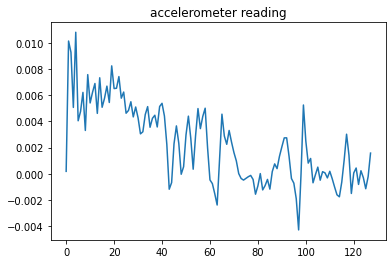

```python
plt.title('accelerometer reading')
plt.plot(df[df["id"] == 0].set_index("time").value)
plt.show()
```

## Extract Features

```python
# only use the first 500 ids to speed up the processing
X = extract_features(df[df["id"] < 500], column_id="id", column_sort="time", impute_function=impute)
```

```python
X.head()
```

|  | value__variance_larger_than_standard_deviation | value__has_duplicate_max | value__has_duplicate_min | value__has_duplicate | value__sum_values | value__abs_energy | value__mean_abs_change | value__mean_change | value__mean_second_derivative_central | value__median | ... | value__permutation_entropy__dimension_6__tau_1 | value__permutation_entropy__dimension_7__tau_1 | value__query_similarity_count__query_None__threshold_0.0 | value__matrix_profile__feature_"min"__threshold_0.98 | value__matrix_profile__feature_"max"__threshold_0.98 | value__matrix_profile__feature_"mean"__threshold_0.98 | value__matrix_profile__feature_"median"__threshold_0.98 | value__matrix_profile__feature_"25"__threshold_0.98 | value__matrix_profile__feature_"75"__threshold_0.98 | value__mean_n_absolute_max__number_of_maxima_7 |
| --- | --- | --- | --- | --- | --- | --- | --- | --- | --- | --- | --- | --- | --- | --- | --- | --- | --- | --- | --- | --- | --- |
| 0 | 0.0 | 0.0 | 0.0 | 0.0 | 0.290392 | 0.001766 | 0.001435 | 0.000011 | -0.000032 | 0.002025 | ... | 4.555721 | 4.724480 | 0.0 | 1.111900 | 2.837645 | 1.800238 | 1.731414 | 1.464639 | 2.113387 | 0.008684 |
| 1 | 0.0 | 0.0 | 0.0 | 0.0 | 0.022239 | 0.000506 | 0.001323 | -0.000021 | -0.000008 | 0.000110 | ... | 4.520418 | 4.747206 | 0.0 | 0.785462 | 2.741869 | 1.615160 | 1.608568 | 1.329079 | 1.895041 | 0.005250 |
| 2 | 0.0 | 0.0 | 0.0 | 0.0 | 0.054796 | 0.001106 | 0.001827 | -0.000011 | 0.000001 | 0.000627 | ... | 4.409911 | 4.735843 | 0.0 | 0.913254 | 3.107882 | 1.692529 | 1.614387 | 1.329484 | 1.952855 | 0.007916 |
| 3 | 0.0 | 0.0 | 0.0 | 0.0 | 0.042157 | 0.000932 | 0.001470 | 0.000014 | 0.000003 | 0.000269 | ... | 4.335833 | 4.686101 | 0.0 | 0.897427 | 2.796923 | 1.656214 | 1.683194 | 1.404298 | 1.864329 | 0.007687 |
| 4 | 0.0 | 0.0 | 0.0 | 0.0 | -0.024980 | 0.000525 | 0.001215 | -0.000027 | -0.000007 | -0.000144 | ... | 4.350795 | 4.656301 | 0.0 | 1.231613 | 2.762502 | 1.926316 | 1.957036 | 1.647432 | 2.165181 | 0.004961 |

5 rows × 789 columns

## Train and evaluate classifier

For later comparison, we train a decision tree on all features (without selection):

```python
X_train, X_test, y_train, y_test = train_test_split(X, y[:500], test_size=.2)
```

```python
classifier_full = DecisionTreeClassifier()
classifier_full.fit(X_train, y_train)
print(classification_report(y_test, classifier_full.predict(X_test)))
```

```
              precision    recall  f1-score   support

           1       0.81      0.91      0.86        23
           2       0.88      0.93      0.90        15
           3       1.00      0.73      0.85        15
           4       0.46      0.33      0.39        18
           5       0.35      0.43      0.39        14
           6       0.35      0.40      0.38        15

    accuracy                           0.64       100
   macro avg       0.64      0.62      0.63       100
weighted avg       0.65      0.64      0.64       100
```

# Multiclass feature selection

We will now select a subset of relevant features using the `tsfresh` select features method. However it only works for binary classification or regression tasks.

For a 6 label multi classification we therefore split the selection problem into 6 binary one-versus all classification problems. For each of them we can do a binary classification feature selection:

```python
relevant_features = set()

for label in y.unique():
    y_train_binary = y_train == label
    X_train_filtered = select_features(X_train, y_train_binary)
    print("Number of relevant features for class {}: {}/{}".format(label, X_train_filtered.shape[1], X_train.shape[1]))
    relevant_features = relevant_features.union(set(X_train_filtered.columns))
```

```
Number of relevant features for class 5: 244/789
Number of relevant features for class 4: 218/789
Number of relevant features for class 6: 206/789
Number of relevant features for class 1: 237/789
Number of relevant features for class 3: 256/789
Number of relevant features for class 2: 179/789
```

```python
len(relevant_features)
```

```
310
```

we keep only those features that we selected above, for both the train and test set

```python
X_train_filtered = X_train[list(relevant_features)]
X_test_filtered = X_test[list(relevant_features)]
```

and train again:

```python
classifier_selected = DecisionTreeClassifier()
classifier_selected.fit(X_train_filtered, y_train)
print(classification_report(y_test, classifier_selected.predict(X_test_filtered)))
```

```
              precision    recall  f1-score   support

           1       0.81      0.91      0.86        23
           2       0.81      0.87      0.84        15
           3       1.00      0.73      0.85        15
           4       0.38      0.33      0.35        18
           5       0.38      0.43      0.40        14
           6       0.27      0.27      0.27        15

    accuracy                           0.61       100
   macro avg       0.61      0.59      0.59       100
weighted avg       0.62      0.61      0.61       100
```

## Improved Multiclass feature selection

We can instead specify the number of classes for which a feature should be a relevant predictor in order to pass through the filtering process. This is as simple as setting the `multiclass` parameter to `True` and setting `n_significant` to the required number of classes. We will try with a requirement of being relevant for 5 classes.

```python
X_train_filtered_multi = select_features(X_train, y_train, multiclass=True, n_significant=5)
X_train_filtered_multi.shape
```

```
(400, 190)
```

We can see that the number of relevant features is lower than the previous implementation.

```python
classifier_selected_multi = DecisionTreeClassifier()
classifier_selected_multi.fit(X_train_filtered_multi, y_train)
X_test_filtered_multi = X_test[X_train_filtered_multi.columns]
print(classification_report(y_test, classifier_selected_multi.predict(X_test_filtered_multi)))
```

```
              precision    recall  f1-score   support

           1       0.95      0.87      0.91        23
           2       0.78      0.93      0.85        15
           3       1.00      0.93      0.97        15
           4       0.46      0.33      0.39        18
           5       0.50      0.43      0.46        14
           6       0.45      0.67      0.54        15

    accuracy                           0.70       100
   macro avg       0.69      0.69      0.69       100
weighted avg       0.71      0.70      0.70       100
```

We now get slightly better classification performance, especially for classes where the previous classifier performed poorly. The parameter `n_significant` can be tuned for best results.

# Timeseries Forecasting

This notebook explains how to use `tsfresh` in time series foreacasting. Make sure you also read through the [documentation](https://tsfresh.readthedocs.io/en/latest/text/forecasting.html) to learn more on this feature.

We will use the stock price of Apple for this. In this notebook we will only showcase how to work with a single time series at a time (one stock). There exist another notebook in the `advanced` folder, which treats several stocks at the same time. Basically the same - but a bit more complex when it comes to pandas multi-indexing.

## Reading the data

We download the data from "stooq" and only store the High value. Please note: this notebook is for showcasing `tsfresh`s feature extraction - not to predict stock market prices :-)

```python
df = web.DataReader("AAPL", 'stooq')["High"]
df.head()
```

```
Date
2022-10-04    146.2200
2022-10-03    143.0700
2022-09-30    143.1000
2022-09-29    146.7200
2022-09-28    150.6414
Name: High, dtype: float64
```

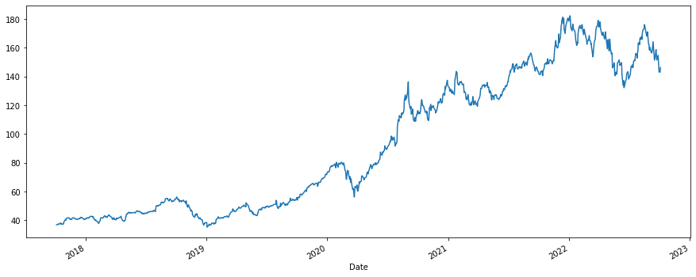

```python
plt.figure(figsize=(15, 6))
df.plot(ax=plt.gca())
plt.show()
```

```python
df_melted = pd.DataFrame({"high": df.copy()})
df_melted["date"] = df_melted.index
df_melted["Symbols"] = "AAPL"

df_melted.head()
```

| Date | high | date | Symbols |
| --- | --- | --- | --- |
| 2022-10-04 | 146.2200 | 2022-10-04 | AAPL |
| 2022-10-03 | 143.0700 | 2022-10-03 | AAPL |
| 2022-09-30 | 143.1000 | 2022-09-30 | AAPL |
| 2022-09-29 | 146.7200 | 2022-09-29 | AAPL |
| 2022-09-28 | 150.6414 | 2022-09-28 | AAPL |

## Create training data sample

Forecasting typically involves the following steps:

- take all data up to today
- do feature extraction (e.g. by running `extract_features`)
- run a prediction model (e.g. a regressor, see below)
- use the result as the forecast for tomorrow

In training however, we need multiple examples to train. If we would only use the time series until today (and wait for the value of tomorrow to have a target), we would only have a single training example. Therefore we use a trick: we replay the history.

Imagine you have a cut-out window sliding over your data. At each time step $t$, you treat the data as it would be today. You extract the features with everything you know until today (which is all data until and including $t$). The target for the features until time $t$ is the time value of time $t + 1$ (which you already know, because everything has already happened).

The process of window-sliding is implemented in the function `roll_time_series`. Our window size will be 20 (we look at max 20 days in the past) and we disregard all windows which are shorter than 5 days.

```python
df_rolled = roll_time_series(df_melted, column_id="Symbols", column_sort="date",
                             max_timeshift=20, min_timeshift=5)
```

```python
df_rolled.head()
```

|  | high | date | Symbols | id |
| --- | --- | --- | --- | --- |
| 0 | 36.8828 | 2017-10-05 | AAPL | (AAPL, 2017-10-12 00:00:00) |
| 1 | 36.8928 | 2017-10-06 | AAPL | (AAPL, 2017-10-12 00:00:00) |
| 2 | 37.1824 | 2017-10-09 | AAPL | (AAPL, 2017-10-12 00:00:00) |
| 3 | 37.4899 | 2017-10-10 | AAPL | (AAPL, 2017-10-12 00:00:00) |
| 4 | 37.2413 | 2017-10-11 | AAPL | (AAPL, 2017-10-12 00:00:00) |

The resulting dataframe now consists of these "windows" stamped out of the original dataframe. For example all data with the `id = (AAPL, 2020-07-14 00:00:00)` comes from the original data of stock `AAPL` including the last 20 days until `2020-07-14`:

```python
df_rolled[df_rolled["id"] == ("AAPL", pd.to_datetime("2020-07-14"))]
```

|  | high | date | Symbols | id |
| --- | --- | --- | --- | --- |
| 14391 | 85.2366 | 2020-06-15 | AAPL | (AAPL, 2020-07-14 00:00:00) |
| 14392 | 87.0890 | 2020-06-16 | AAPL | (AAPL, 2020-07-14 00:00:00) |
| 14393 | 87.6323 | 2020-06-17 | AAPL | (AAPL, 2020-07-14 00:00:00) |
| 14394 | 87.1509 | 2020-06-18 | AAPL | (AAPL, 2020-07-14 00:00:00) |
| 14395 | 87.9199 | 2020-06-19 | AAPL | (AAPL, 2020-07-14 00:00:00) |
| 14396 | 88.6319 | 2020-06-22 | AAPL | (AAPL, 2020-07-14 00:00:00) |
| 14397 | 91.8205 | 2020-06-23 | AAPL | (AAPL, 2020-07-14 00:00:00) |
| 14398 | 90.9337 | 2020-06-24 | AAPL | (AAPL, 2020-07-14 00:00:00) |
| 14399 | 89.9980 | 2020-06-25 | AAPL | (AAPL, 2020-07-14 00:00:00) |
| 14400 | 90.0769 | 2020-06-26 | AAPL | (AAPL, 2020-07-14 00:00:00) |
| 14401 | 89.3010 | 2020-06-29 | AAPL | (AAPL, 2020-07-14 00:00:00) |
| 14402 | 90.2416 | 2020-06-30 | AAPL | (AAPL, 2020-07-14 00:00:00) |
| 14403 | 90.5812 | 2020-07-01 | AAPL | (AAPL, 2020-07-14 00:00:00) |
| 14404 | 91.3471 | 2020-07-02 | AAPL | (AAPL, 2020-07-14 00:00:00) |
| 14405 | 92.6553 | 2020-07-06 | AAPL | (AAPL, 2020-07-14 00:00:00) |
| 14406 | 93.3573 | 2020-07-07 | AAPL | (AAPL, 2020-07-14 00:00:00) |
| 14407 | 94.0663 | 2020-07-08 | AAPL | (AAPL, 2020-07-14 00:00:00) |
| 14408 | 94.9980 | 2020-07-09 | AAPL | (AAPL, 2020-07-14 00:00:00) |
| 14409 | 94.6645 | 2020-07-10 | AAPL | (AAPL, 2020-07-14 00:00:00) |
| 14410 | 98.5911 | 2020-07-13 | AAPL | (AAPL, 2020-07-14 00:00:00) |
| 14411 | 95.9208 | 2020-07-14 | AAPL | (AAPL, 2020-07-14 00:00:00) |

```python
df_melted[(df_melted["date"] <= pd.to_datetime("2020-07-14")) &
          (df_melted["date"] >= pd.to_datetime("2020-06-15")) &
          (df_melted["Symbols"] == "AAPL")]
```

| Date | high | date | Symbols |
| --- | --- | --- | --- |
| 2020-07-14 | 95.9208 | 2020-07-14 | AAPL |
| 2020-07-13 | 98.5911 | 2020-07-13 | AAPL |
| 2020-07-10 | 94.6645 | 2020-07-10 | AAPL |
| 2020-07-09 | 94.9980 | 2020-07-09 | AAPL |
| 2020-07-08 | 94.0663 | 2020-07-08 | AAPL |
| 2020-07-07 | 93.3573 | 2020-07-07 | AAPL |
| 2020-07-06 | 92.6553 | 2020-07-06 | AAPL |
| 2020-07-02 | 91.3471 | 2020-07-02 | AAPL |
| 2020-07-01 | 90.5812 | 2020-07-01 | AAPL |
| 2020-06-30 | 90.2416 | 2020-06-30 | AAPL |
| 2020-06-29 | 89.3010 | 2020-06-29 | AAPL |
| 2020-06-26 | 90.0769 | 2020-06-26 | AAPL |
| 2020-06-25 | 89.9980 | 2020-06-25 | AAPL |
| 2020-06-24 | 90.9337 | 2020-06-24 | AAPL |
| 2020-06-23 | 91.8205 | 2020-06-23 | AAPL |
| 2020-06-22 | 88.6319 | 2020-06-22 | AAPL |
| 2020-06-19 | 87.9199 | 2020-06-19 | AAPL |
| 2020-06-18 | 87.1509 | 2020-06-18 | AAPL |
| 2020-06-17 | 87.6323 | 2020-06-17 | AAPL |
| 2020-06-16 | 87.0890 | 2020-06-16 | AAPL |
| 2020-06-15 | 85.2366 | 2020-06-15 | AAPL |

If you now group by the new `id` column, each of the groups will be a certain stock symbol until and including the data until a certain day (and including the last 20 days in the past).

```python
len(df_melted)
```

```
1258
```

```python
df_rolled["id"].nunique()
```

```
1253
```

We "lost" 5 windows, as we required to have a minimum history of more than 5 days.

```python
df_rolled.groupby("id").size().agg([np.min, np.max])
```

```
amin     6
amax    21
dtype: int64
```

The process is also shown in this image (please note that the window size is smaller for better visibility):

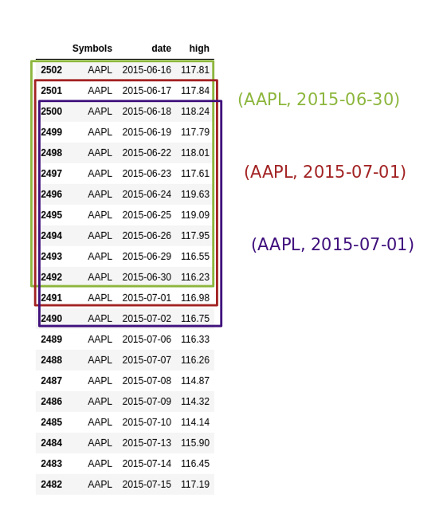

## Extract Features

The rolled (windowed) data sample is now in the correct format to use it for `tsfresh`s feature extraction. As normal, features will be extracted using all data for a given `id`, which is in our case all data of a given window and a given id (one colored box in the graph above).

If the feature extraction returns a row with the index `(AAPL, 2020-07-14 00:00:00)`, you know it has been calculated using the `AAPL` data up and including `2020-07-14` (and 20 days of history).

```python
X = extract_features(df_rolled.drop("Symbols", axis=1),
                     column_id="id", column_sort="date", column_value="high",
                     impute_function=impute, show_warnings=False)
```

```python
X.head()
```

|  |  | high__variance_larger_than_standard_deviation | high__has_duplicate_max | high__has_duplicate_min | high__has_duplicate | high__sum_values | high__abs_energy | high__mean_abs_change | high__mean_change | high__mean_second_derivative_central | high__median | ... | high__permutation_entropy__dimension_6__tau_1 | high__permutation_entropy__dimension_7__tau_1 | high__query_similarity_count__query_None__threshold_0.0 | high__matrix_profile__feature_"min"__threshold_0.98 | high__matrix_profile__feature_"max"__threshold_0.98 | high__matrix_profile__feature_"mean"__threshold_0.98 | high__matrix_profile__feature_"median"__threshold_0.98 | high__matrix_profile__feature_"25"__threshold_0.98 | high__matrix_profile__feature_"75"__threshold_0.98 | high__mean_n_absolute_max__number_of_maxima_7 |
| --- | --- | --- | --- | --- | --- | --- | --- | --- | --- | --- | --- | --- | --- | --- | --- | --- | --- | --- | --- | --- | --- | --- |
| AAPL | 2017-10-12 | 0.0 | 0.0 | 0.0 | 0.0 | 223.0283 | 8290.565914 | 0.190700 | 0.091260 | 0.010975 | 37.21185 | ... | -0.000000 | 2.708050 | 0.0 | 1.441607 | 4.775791 | 2.277535 | 1.808076 | 1.630757 | 2.574085 | 78.893986 |
|  | 2017-10-13 | 0.0 | 0.0 | 0.0 | 0.0 | 260.3455 | 9683.139330 | 0.162567 | 0.072400 | -0.003190 | 37.24130 | ... | 0.693147 | -0.000000 | 0.0 | 1.441607 | 4.775791 | 2.277535 | 1.808076 | 1.630757 | 2.574085 | 78.893986 |
|  | 2017-10-16 | 0.0 | 0.0 | 0.0 | 0.0 | 298.3068 | 11124.199627 | 0.231357 | 0.154071 | 0.052842 | 37.27925 | ... | 1.098612 | 0.693147 | 0.0 | 1.441607 | 4.775791 | 2.277535 | 1.808076 | 1.630757 | 2.574085 | 37.346286 |
|  | 2017-10-17 | 0.0 | 0.0 | 0.0 | 0.0 | 336.4748 | 12580.995851 | 0.228275 | 0.160650 | 0.014050 | 37.31720 | ... | 1.386294 | 1.098612 | 0.0 | 1.441607 | 4.775791 | 2.277535 | 1.808076 | 1.630757 | 2.574085 | 37.528457 |
|  | 2017-10-18 | 0.0 | 0.0 | 0.0 | 0.0 | 374.6058 | 14034.969012 | 0.207022 | 0.138689 | -0.002937 | 37.32815 | ... | 1.609438 | 1.386294 | 0.0 | 1.441607 | 4.775791 | 2.277535 | 1.808076 | 1.630757 | 2.574085 | 37.663971 |

5 rows × 789 columns

We make the data a bit easier to work with by removing the tuple-index

```python
X = X.set_index(X.index.map(lambda x: x[1]), drop=True)
X.index.name = "last_date"
X.head()
```

| last_date | high__variance_larger_than_standard_deviation | high__has_duplicate_max | high__has_duplicate_min | high__has_duplicate | high__sum_values | high__abs_energy | high__mean_abs_change | high__mean_change | high__mean_second_derivative_central | high__median | ... | high__permutation_entropy__dimension_6__tau_1 | high__permutation_entropy__dimension_7__tau_1 | high__query_similarity_count__query_None__threshold_0.0 | high__matrix_profile__feature_"min"__threshold_0.98 | high__matrix_profile__feature_"max"__threshold_0.98 | high__matrix_profile__feature_"mean"__threshold_0.98 | high__matrix_profile__feature_"median"__threshold_0.98 | high__matrix_profile__feature_"25"__threshold_0.98 | high__matrix_profile__feature_"75"__threshold_0.98 | high__mean_n_absolute_max__number_of_maxima_7 |
| --- | --- | --- | --- | --- | --- | --- | --- | --- | --- | --- | --- | --- | --- | --- | --- | --- | --- | --- | --- | --- | --- |
| 2017-10-12 | 0.0 | 0.0 | 0.0 | 0.0 | 223.0283 | 8290.565914 | 0.190700 | 0.091260 | 0.010975 | 37.21185 | ... | -0.000000 | 2.708050 | 0.0 | 1.441607 | 4.775791 | 2.277535 | 1.808076 | 1.630757 | 2.574085 | 78.893986 |
| 2017-10-13 | 0.0 | 0.0 | 0.0 | 0.0 | 260.3455 | 9683.139330 | 0.162567 | 0.072400 | -0.003190 | 37.24130 | ... | 0.693147 | -0.000000 | 0.0 | 1.441607 | 4.775791 | 2.277535 | 1.808076 | 1.630757 | 2.574085 | 78.893986 |
| 2017-10-16 | 0.0 | 0.0 | 0.0 | 0.0 | 298.3068 | 11124.199627 | 0.231357 | 0.154071 | 0.052842 | 37.27925 | ... | 1.098612 | 0.693147 | 0.0 | 1.441607 | 4.775791 | 2.277535 | 1.808076 | 1.630757 | 2.574085 | 37.346286 |
| 2017-10-17 | 0.0 | 0.0 | 0.0 | 0.0 | 336.4748 | 12580.995851 | 0.228275 | 0.160650 | 0.014050 | 37.31720 | ... | 1.386294 | 1.098612 | 0.0 | 1.441607 | 4.775791 | 2.277535 | 1.808076 | 1.630757 | 2.574085 | 37.528457 |
| 2017-10-18 | 0.0 | 0.0 | 0.0 | 0.0 | 374.6058 | 14034.969012 | 0.207022 | 0.138689 | -0.002937 | 37.32815 | ... | 1.609438 | 1.386294 | 0.0 | 1.441607 | 4.775791 | 2.277535 | 1.808076 | 1.630757 | 2.574085 | 37.663971 |

5 rows × 789 columns

Our `(AAPL, 2020-07-14 00:00:00)` is also in the data again:

```python
X.loc['2020-07-14']
```

```
high__variance_larger_than_standard_deviation                1.000000
high__has_duplicate_max                                      0.000000
high__has_duplicate_min                                      0.000000
high__has_duplicate                                          0.000000
high__sum_values                                          1912.213900
                                                             ...
high__matrix_profile__feature_"mean"__threshold_0.98         2.277535
high__matrix_profile__feature_"median"__threshold_0.98       1.808076
high__matrix_profile__feature_"25"__threshold_0.98           1.630757
high__matrix_profile__feature_"75"__threshold_0.98           2.574085
high__mean_n_absolute_max__number_of_maxima_7               94.893329
Name: 2020-07-14 00:00:00, Length: 789, dtype: float64
```

## Prediction

We can now use the extracted features to train a regressor. But what will be our targets? The target for the row `2020-07-13` is the value on the next timestep (that would be `2020-07-14` in this case).

So all we need to do is go back to our original dataframe and take the stock value of tomorrow. This is done with `shift`:

```python
y = df_melted.set_index("date").sort_index().high.shift(-1)
```

Quick consistency test:

```python
y["2020-07-13"], df["2020-07-14"].iloc[0]
```

```
(95.9208, 95.9208)
```

However, we need to be a bit careful here: `X` is missing the first 5 dates (as our minimum window size was 5) and `y` is missing the last date (as there is nothing to predict on today). So lets make sure we have a consistent view on the data.

```python
y = y[y.index.isin(X.index)]
X = X[X.index.isin(y.index)]
```

```python
X[:"2018"]
```

| last_date | high__variance_larger_than_standard_deviation | high__has_duplicate_max | high__has_duplicate_min | high__has_duplicate | high__sum_values | high__abs_energy | high__mean_abs_change | high__mean_change | high__mean_second_derivative_central | high__median | ... | high__permutation_entropy__dimension_6__tau_1 | high__permutation_entropy__dimension_7__tau_1 | high__query_similarity_count__query_None__threshold_0.0 | high__matrix_profile__feature_"min"__threshold_0.98 | high__matrix_profile__feature_"max"__threshold_0.98 | high__matrix_profile__feature_"mean"__threshold_0.98 | high__matrix_profile__feature_"median"__threshold_0.98 | high__matrix_profile__feature_"25"__threshold_0.98 | high__matrix_profile__feature_"75"__threshold_0.98 | high__mean_n_absolute_max__number_of_maxima_7 |
| --- | --- | --- | --- | --- | --- | --- | --- | --- | --- | --- | --- | --- | --- | --- | --- | --- | --- | --- | --- | --- | --- |
| 2017-10-12 | 0.0 | 0.0 | 0.0 | 0.0 | 223.0283 | 8290.565914 | 0.190700 | 0.091260 | 0.010975 | 37.21185 | ... | -0.000000 | 2.708050 | 0.0 | 1.441607 | 4.775791 | 2.277535 | 1.808076 | 1.630757 | 2.574085 | 78.893986 |
| 2017-10-13 | 0.0 | 0.0 | 0.0 | 0.0 | 260.3455 | 9683.139330 | 0.162567 | 0.072400 | -0.003190 | 37.24130 | ... | 0.693147 | -0.000000 | 0.0 | 1.441607 | 4.775791 | 2.277535 | 1.808076 | 1.630757 | 2.574085 | 78.893986 |
| 2017-10-16 | 0.0 | 0.0 | 0.0 | 0.0 | 298.3068 | 11124.199627 | 0.231357 | 0.154071 | 0.052842 | 37.27925 | ... | 1.098612 | 0.693147 | 0.0 | 1.441607 | 4.775791 | 2.277535 | 1.808076 | 1.630757 | 2.574085 | 37.346286 |
| 2017-10-17 | 0.0 | 0.0 | 0.0 | 0.0 | 336.4748 | 12580.995851 | 0.228275 | 0.160650 | 0.014050 | 37.31720 | ... | 1.386294 | 1.098612 | 0.0 | 1.441607 | 4.775791 | 2.277535 | 1.808076 | 1.630757 | 2.574085 | 37.528457 |
| 2017-10-18 | 0.0 | 0.0 | 0.0 | 0.0 | 374.6058 | 14034.969012 | 0.207022 | 0.138689 | -0.002937 | 37.32815 | ... | 1.609438 | 1.386294 | 0.0 | 1.441607 | 4.775791 | 2.277535 | 1.808076 | 1.630757 | 2.574085 | 37.663971 |
| ... | ... | ... | ... | ... | ... | ... | ... | ... | ... | ... | ... | ... | ... | ... | ... | ... | ... | ... | ... | ... | ... |
| 2018-12-24 | 1.0 | 0.0 | 0.0 | 0.0 | 874.4064 | 36489.023837 | 0.668570 | -0.302880 | -0.031458 | 41.70910 | ... | 2.566599 | 2.615631 | 0.0 | 1.441607 | 4.775791 | 2.277535 | 1.808076 | 1.630757 | 2.574085 | 43.618414 |
| 2018-12-26 | 1.0 | 0.0 | 0.0 | 0.0 | 869.7209 | 36110.979424 | 0.717005 | -0.214105 | 0.037266 | 41.55030 | ... | 2.479956 | 2.615631 | 0.0 | 1.441607 | 4.775791 | 2.277535 | 1.808076 | 1.630757 | 2.574085 | 43.554786 |
| 2018-12-27 | 1.0 | 0.0 | 0.0 | 0.0 | 865.3270 | 35758.726173 | 0.720395 | -0.217495 | -0.044595 | 41.52030 | ... | 2.479956 | 2.615631 | 0.0 | 1.441607 | 4.775791 | 2.277535 | 1.808076 | 1.630757 | 2.574085 | 43.548500 |
| 2018-12-28 | 1.0 | 0.0 | 0.0 | 0.0 | 861.3985 | 35442.300819 | 0.662325 | -0.275565 | 0.001682 | 41.10890 | ... | 2.479956 | 2.615631 | 0.0 | 1.441607 | 4.775791 | 2.277535 | 1.808076 | 1.630757 | 2.574085 | 43.538514 |
| 2018-12-31 | 1.0 | 0.0 | 0.0 | 0.0 | 856.0959 | 35005.697461 | 0.654885 | -0.283005 | 0.021153 | 40.86620 | ... | 2.479956 | 2.615631 | 0.0 | 1.441607 | 4.775791 | 2.277535 | 1.808076 | 1.630757 | 2.574085 | 43.236943 |

306 rows × 789 columns

```python
X_train = X[:"2018"]
X_test = X["2019":]

y_train = y[:"2018"]
y_test = y["2019":]
```

and do feature selection before training

```python
X_train_selected = select_features(X_train, y_train)
```

```python
ada = LinearRegression()

ada.fit(X_train_selected, y_train)
```

```
LinearRegression()
```

Now lets check how good our prediction is:

```python
X_test_selected = X_test[X_train_selected.columns]

y_pred = pd.Series(ada.predict(X_test_selected), index=X_test_selected.index)
```

The prediction is for the next day, so for drawing we need to shift 1 step back:

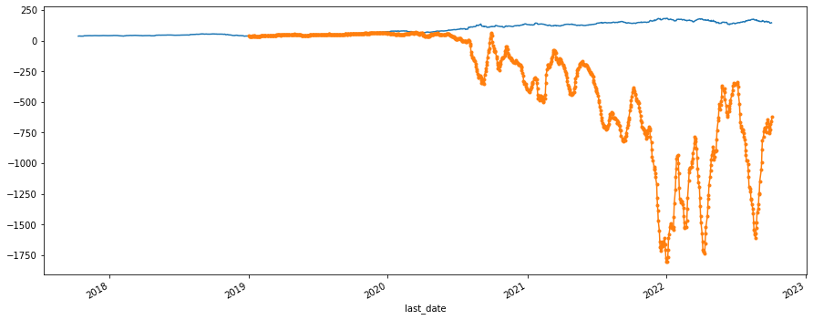

```python
plt.figure(figsize=(15, 6))

y.plot(ax=plt.gca())
y_pred.plot(ax=plt.gca(), legend=None, marker=".")
```

Well, clearly not perfect ;-)

# REFERENCIAS

The TSFRESH package is described in the following open access paper:

Christ, M., Braun, N., Neuffer, J., and Kempa-Liehr A.W. (2018). Time Series FeatuRe Extraction on basis of Scalable Hypothesis tests (tsfresh -- A Python package). Neurocomputing 307 (2018) 72-77, doi: 10.1016/j.neucom.2018.03.067. The FRESH algorithm is described in the following whitepaper:

Christ, M., Kempa-Liehr, A.W., and Feindt, M. (2017). Distributed and parallel time series feature extraction for industrial big data applications. ArXiv e-print 1610.07717, https://arxiv.org/abs/1610.07717.